# Data_Driven_E_commerce_Inventory_and_Sales_Performance_Optimization (1)

**Data-Driven E-commerce Inventory and Sales Performance Optimization**

**Introduction**

In today’s competitive retail environment, maximizing profitability while ensuring customer satisfaction requires effective product performance tracking and inventory management. This project leverages data analytics to uncover patterns in sales, profitability, and product affinity to support better decision-making.

**Business Problem**

The client company struggles to identify which products drive profitability, which underperform, and how to optimize inventory levels without overspending. Inefficient stock management and lack of visibility into product performance limit both revenue growth and customer satisfaction.

**Objectives**

1.To analyze product performance and profitability across categories and time periods.

2.To identify underperforming products and highlight best sellers.

3.To evaluate product affinity for cross-selling and promotional opportunities.

4.To optimize inventory allocation strategies based on demand and profitability trends.

5.To provide actionable, data-driven recommendations for improving sales and operational efficiency.

**Data Sources**

Dataset: https://www.kaggle.com/datasets/mashlyn/online-retail-ii-uci

**Data Analysis Roadmap**

1.Importing Required Libraries

2.Loading the Dataset

3.Introducing Missingness (Data Quality Simulation)

4.Unclean Dataset Overview

5.Data Cleaning & Preprocessing

6.Exploratory Data Analysis

6.1 Business Question 1

6.2 Business Question 2

6.3 Business Question 3

6.4 Business Question 4

6.5 Business Question 5

6.6 Business Question 6

Conclusion

References

1. Importing required Libraries for the project

```python
import pandas as pd
import numpy as np
import matplotlib.pyplot as plt
import seaborn as sns
import plotly.express as px
```

2. Loading the dataset

```python
#  Load the dataset
file_path = "/content/online_retail_II.xlsx"
df = pd.read_excel(file_path, sheet_name="Year 2009-2010")
```

3. Introducing Missingness (Data Quality Simulation)

```python
#  Set random seed for reproducibility
rng = np.random.default_rng(seed=123)

def introduce_missing(series, percent):
    n_missing = int(len(series) * percent)
    idx = rng.choice(series.index, size=n_missing, replace=False)
    series = series.copy()
    series.loc[idx] = np.nan
    return series
```

```python
#  Target missing percentages
missing_percents = {
    "Invoice": 0.10,
    "StockCode": 0.15,
    "Description": 0.50,
    "Quantity": 0.08,
    "InvoiceDate": 0.12,
    "Price": 0.20,
    "Customer ID": 0.35,
    "Country": 0.18
}
```

```python
#  Apply missingness
df_missing = df.copy()
for col, perc in missing_percents.items():
    if col in df_missing.columns:
        df_missing[col] = introduce_missing(df_missing[col], perc)
```

```python
# Save to new Excel
df_missing.to_excel("online_retail_II_injected_missing.xlsx", index=False)
print("New file saved as online_retail_II_injected_missing.xlsx")
```

```
New file saved as online_retail_II_injected_missing.xlsx
```

```python
#  Load dataset
file_path = "/content/online_retail_II_injected_missing.xlsx"
df = pd.read_excel(file_path, engine="openpyxl")
print("Raw shape:", df.shape)
```

```
Raw shape: (525461, 8)
```

```python
#  Normalize column names
df.columns = df.columns.str.strip().str.lower().str.replace(" ", "_")
print("Columns:", df.columns.tolist())
```

```
Columns: ['invoice', 'stockcode', 'description', 'quantity', 'invoicedate', 'price', 'customer_id', 'country']
```

4. Unclean Dataset Overview

```python
# Missingness summary
missing = df.isna().sum().to_frame("missing_count")
missing["missing_percent"] = (df.isna().mean() * 100).round(2)
print("\n--- Missingness by column ---")
display(missing.sort_values("missing_percent", ascending=False))
```

```
--- Missingness by column ---
```

|  | missing_count | missing_percent |
| --- | --- | --- |
| description | 264185 | 50.28 |
| customer_id | 253780 | 48.30 |
| price | 105092 | 20.00 |
| country | 94582 | 18.00 |
| stockcode | 78819 | 15.00 |
| invoicedate | 63055 | 12.00 |
| invoice | 52546 | 10.00 |
| quantity | 42036 | 8.00 |

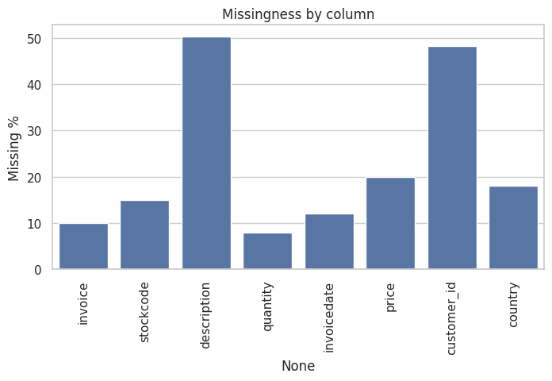

```python
# Visualize missingness
plt.figure(figsize=(8,4))
sns.barplot(x=missing.index, y=missing["missing_percent"])
plt.xticks(rotation=90)
plt.ylabel("Missing %")
plt.title("Missingness by column")
plt.show()
```

5. Data Cleaning & Preprocessing

```python
# Drop duplicates
print("Before removing duplicates:", df.shape)
df = df.drop_duplicates()
print("After removing duplicates:", df.shape)
```

```
Before removing duplicates: (525461, 8)
After removing duplicates: (523731, 8)
```

```python
#  Handle invalid prices
invalid_prices = (df["price"] <= 0).sum()
print(f"Rows with Price <= 0: {invalid_prices}")
df = df[df["price"] > 0]
```

```
Rows with Price <= 0: 2951
```

```python
#  Handle missing critical IDs
missing_invoice = df["invoice"].isna().sum()
missing_country = df["country"].isna().sum()
print(f"Missing invoice: {missing_invoice}, Missing country: {missing_country}")

df = df.dropna(subset=["invoice", "country"])
```

```
Missing invoice: 41586, Missing country: 75068
```

```python
  # Handle customer_id
missing_cust = df["customer_id"].isna().sum()
print(f"Missing customer_id (before): {missing_cust}")
# Keep them for product-level analysis, but flag
df["customer_missing_flag"] = df["customer_id"].isna().astype(int)
```

```
Missing customer_id (before): 147188
```

```python
#  Data type conversions
df["invoice"] = df["invoice"].astype(str)
df["customer_id"] = df["customer_id"].astype(str)
df["invoicedate"] = pd.to_datetime(df["invoicedate"], errors="coerce")
```

```python
#  Feature engineering
df["total_value"] = df["quantity"] * df["price"]
df["year"] = df["invoicedate"].dt.year
df["month"] = df["invoicedate"].dt.month
df["day_of_week"] = df["invoicedate"].dt.day_name()
```

```python
#  Flag cancellations
df["is_cancellation"] = df["invoice"].str.contains("C", na=False).astype(int)

print("\n--- CLEANING DONE ---")
print("Final shape:", df.shape)
display(df.head())
```

```
--- CLEANING DONE ---
Final shape: (307246, 14)
```

|  | invoice | stockcode | description | quantity | invoicedate | price | customer_id | country | customer_missing_flag | total_value | year | month | day_of_week | is_cancellation |
| --- | --- | --- | --- | --- | --- | --- | --- | --- | --- | --- | --- | --- | --- | --- |
| 0 | 489434 | 85048 | 15CM CHRISTMAS GLASS BALL 20 LIGHTS | 12.0 | 2009-12-01 07:45:00 | 6.95 | 13085.0 | United Kingdom | 0 | 83.4 | 2009.0 | 12.0 | Tuesday | 0 |
| 4 | 489434 | NaN | STRAWBERRY CERAMIC TRINKET BOX | 24.0 | 2009-12-01 07:45:00 | 1.25 | 13085.0 | United Kingdom | 0 | 30.0 | 2009.0 | 12.0 | Tuesday | 0 |
| 5 | 489434 | 22064 | NaN | 24.0 | 2009-12-01 07:45:00 | 1.65 | 13085.0 | United Kingdom | 0 | 39.6 | 2009.0 | 12.0 | Tuesday | 0 |
| 6 | 489434 | 21871 | SAVE THE PLANET MUG | 24.0 | 2009-12-01 07:45:00 | 1.25 | 13085.0 | United Kingdom | 0 | 30.0 | 2009.0 | 12.0 | Tuesday | 0 |
| 8 | 489435 | 22350 | NaN | 12.0 | 2009-12-01 07:46:00 | 2.55 | nan | United Kingdom | 1 | 30.6 | 2009.0 | 12.0 | Tuesday | 0 |

```python
# Flag returns (negative quantity)
df["is_return"] = (df["quantity"] < 0).astype(int)
```

```python
#  Hour of purchase (for intra-day patterns)
df["hour"] = df["invoicedate"].dt.hour
```

```python
#  Customer-level RFM features
# Reference date = max invoice date in dataset
ref_date = df["invoicedate"].max()

rfm = df.groupby("customer_id").agg({
    "invoicedate": lambda x: (ref_date - x.max()).days,  # recency
    "invoice": "nunique",                               # frequency
    "total_value": "sum"                                # monetary
}).reset_index()

rfm.columns = ["customer_id", "recency", "frequency", "monetary"]

print("\n      RFM Summary")
display(rfm.describe())
```

```
      RFM Summary
```

|  | recency | frequency | monetary |
| --- | --- | --- | --- |
| count | 4226.000000 | 4248.000000 | 4.248000e+03 |
| mean | 91.163275 | 9.170433 | 1.241755e+03 |
| std | 97.256605 | 293.110150 | 3.515697e+04 |
| min | 0.000000 | 1.000000 | -1.095350e+04 |
| 25% | 18.000000 | 1.000000 | 1.036775e+02 |
| 50% | 52.000000 | 3.000000 | 2.478300e+02 |
| 75% | 140.000000 | 5.000000 | 6.024375e+02 |
| max | 373.000000 | 19101.000000 | 2.283224e+06 |

```python
# Country-level sales & returns
country_summary = df.groupby("country").agg({
    "total_value": "sum",
    "is_return": "sum",
    "invoice": "nunique"
}).reset_index().sort_values("total_value", ascending=False)

print("\n--- Top 10 Countries by Sales ---")
display(country_summary.head(10))
```

```
--- Top 10 Countries by Sales ---
```

|  | country | total_value | is_return | invoice |
| --- | --- | --- | --- | --- |
| 37 | United Kingdom | 4528474.559 | 4699 | 21190 |
| 10 | EIRE | 197717.400 | 100 | 397 |
| 24 | Netherlands | 137489.000 | 19 | 135 |
| 13 | Germany | 106521.840 | 250 | 458 |
| 12 | France | 75670.050 | 121 | 283 |
| 32 | Sweden | 31160.920 | 8 | 74 |
| 9 | Denmark | 27533.530 | 10 | 31 |
| 33 | Switzerland | 23943.440 | 11 | 46 |
| 31 | Spain | 23907.730 | 21 | 72 |
| 0 | Australia | 15644.150 | 13 | 42 |

```python
#  Save engineered datasets for later analysis
rfm.to_csv("sample_data/customer_rfm.csv", index=False)
country_summary.to_csv("sample_data/country_summary.csv", index=False)

print("\nFeature engineering complete. Files saved:")
print("- sample_data/customer_rfm.csv")
print("-sample_ data/processed/country_summary.csv")

# quick peek
display(df.head())
```

```
Feature engineering complete. Files saved:
- sample_data/customer_rfm.csv
-sample_ data/processed/country_summary.csv
```

|  | invoice | stockcode | description | quantity | invoicedate | price | customer_id | country | customer_missing_flag | total_value | year | month | day_of_week | is_cancellation | is_return | hour |
| --- | --- | --- | --- | --- | --- | --- | --- | --- | --- | --- | --- | --- | --- | --- | --- | --- |
| 0 | 489434 | 85048 | 15CM CHRISTMAS GLASS BALL 20 LIGHTS | 12.0 | 2009-12-01 07:45:00 | 6.95 | 13085.0 | United Kingdom | 0 | 83.4 | 2009.0 | 12.0 | Tuesday | 0 | 0 | 7.0 |
| 4 | 489434 | NaN | STRAWBERRY CERAMIC TRINKET BOX | 24.0 | 2009-12-01 07:45:00 | 1.25 | 13085.0 | United Kingdom | 0 | 30.0 | 2009.0 | 12.0 | Tuesday | 0 | 0 | 7.0 |
| 5 | 489434 | 22064 | NaN | 24.0 | 2009-12-01 07:45:00 | 1.65 | 13085.0 | United Kingdom | 0 | 39.6 | 2009.0 | 12.0 | Tuesday | 0 | 0 | 7.0 |
| 6 | 489434 | 21871 | SAVE THE PLANET MUG | 24.0 | 2009-12-01 07:45:00 | 1.25 | 13085.0 | United Kingdom | 0 | 30.0 | 2009.0 | 12.0 | Tuesday | 0 | 0 | 7.0 |
| 8 | 489435 | 22350 | NaN | 12.0 | 2009-12-01 07:46:00 | 2.55 | nan | United Kingdom | 1 | 30.6 | 2009.0 | 12.0 | Tuesday | 0 | 0 | 7.0 |

6. Exploratory Data Analysis

```python
#  EDA
import warnings
warnings.filterwarnings("ignore")  # suppress warnings
sns.set_theme(style="whitegrid")

pd.options.mode.chained_assignment = None  # avoid SettingWithCopyWarning

#  0. Ensure invoicedate is datetime and create key columns
df['invoicedate'] = pd.to_datetime(df['invoicedate'], errors='coerce')
df = df[~df['invoicedate'].isna()].copy()  # drop rows with invalid dates

# Derived columns
df['hour'] = df['invoicedate'].dt.hour
df['day_of_week'] = df['invoicedate'].dt.day_name()
df['month'] = df['invoicedate'].dt.to_period('M').astype(str)

# Create total_value if missing
if 'total_value' not in df.columns:
    df['total_value'] = df['unitprice'] * df['quantity']

# Create RFM if not present
if 'rfm' not in globals():
    ref_date = df['invoicedate'].max()
    rfm = (df.groupby('customer_id')
           .agg(recency=('invoicedate', lambda x: (ref_date - x.max()).days),
                frequency=('invoice', 'nunique'),
                monetary=('total_value', 'sum'))
           .reset_index())
else:
    rfm = rfm.copy()

# Create country_summary if not present
if 'country_summary' not in globals():
    country_summary = (df.groupby('country')
                       .agg(total_value=('total_value', 'sum'),
                            is_return=('quantity', lambda x: (x < 0).sum()),
                            invoice_count=('invoice', 'nunique'))
                       .reset_index()
                       .sort_values('total_value', ascending=False))
else:
    country_summary = country_summary.copy()
```

6.1 Business Question 1:

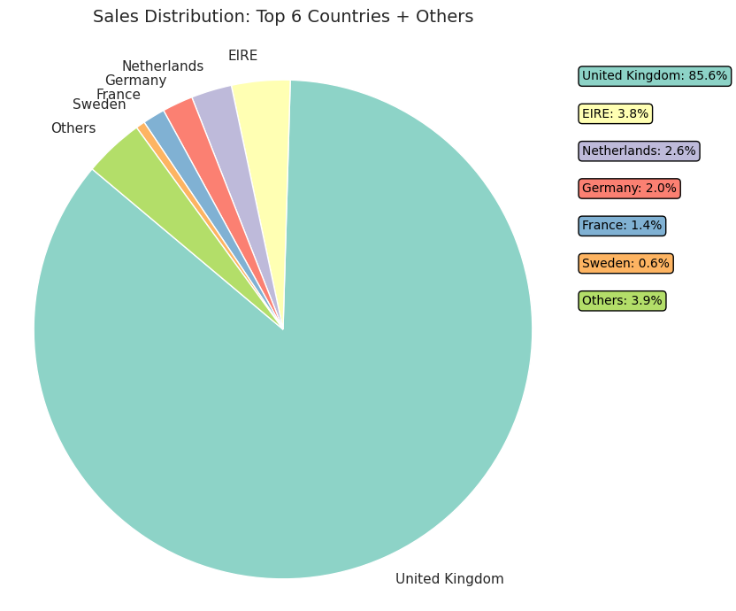

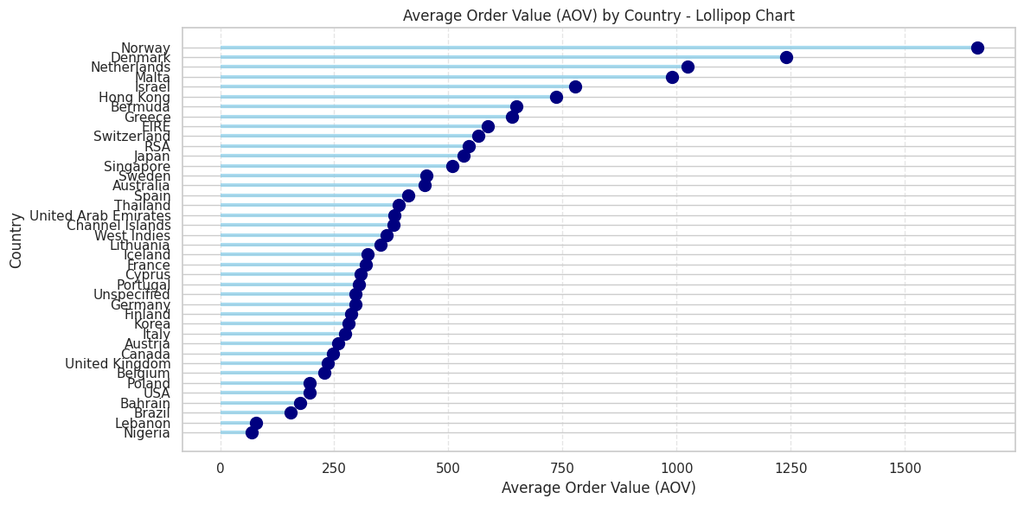

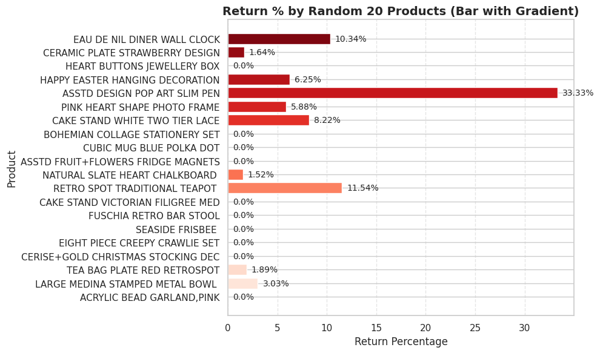

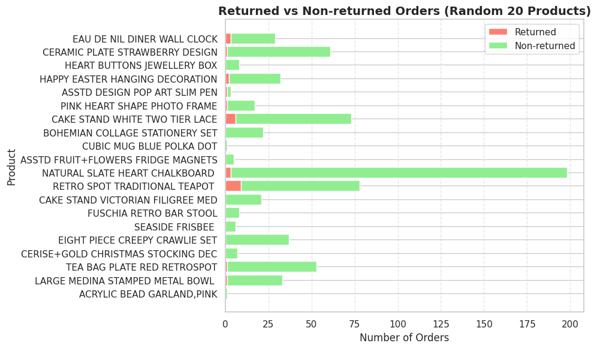

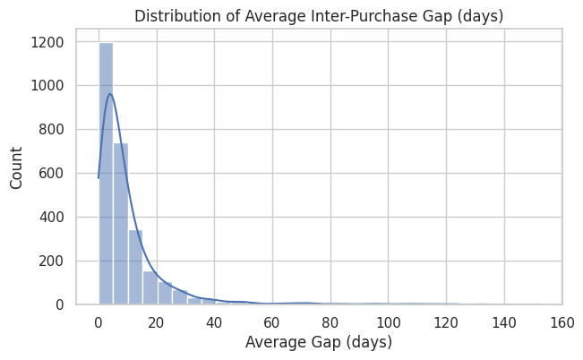

```python
# Aggregate sales
country_sales = df.groupby('country')['total_value'].sum().sort_values(ascending=False)
top6 = country_sales.head(6)
others = country_sales[6:].sum()
top6['Others'] = others

# Colors
colors = plt.cm.Set3.colors[:len(top6)]

# Create figure with extra space for title
plt.figure(figsize=(8,8))
wedges, texts = plt.pie(
    top6,
    labels=top6.index,
    startangle=140,
    colors=colors
)

# Add title higher above the chart
plt.title("Sales Distribution: Top 6 Countries + Others", fontsize=14, y=1.05)

plt.axis('equal')

# Add colored percentage boxes at top-right
total = top6.sum()
for i, (label, value) in enumerate(top6.items()):
    percentage = value / total * 100
    plt.text(
        1.2, 1 - i*0.15,                       # x,y position
        f"{label}: {percentage:.1f}%",
        color='black',
        fontsize=10,
        bbox=dict(facecolor=colors[i], edgecolor='black', boxstyle='round,pad=0.3')
    )

plt.show()


import matplotlib.pyplot as plt
import pandas as pd

# Filter cancellations
df_q17 = df[df['is_cancellation']==False].copy()

# Aggregate: AOV per country
aov_country = df_q17.groupby('country').agg(
    total_value=('total_value','sum'),
    total_invoices=('invoice','nunique')
).reset_index()
aov_country['AOV'] = (aov_country['total_value'] / aov_country['total_invoices']).round(2)

# Sort by AOV
aov_country = aov_country.sort_values('AOV', ascending=True)

#  Lollipop Chart
plt.figure(figsize=(12,6))
plt.hlines(y=aov_country['country'], xmin=0, xmax=aov_country['AOV'], color='skyblue', alpha=0.7, linewidth=3)
plt.plot(aov_country['AOV'], aov_country['country'], "o", markersize=10, color='navy')
plt.xlabel("Average Order Value (AOV)")
plt.ylabel("Country")
plt.title("Average Order Value (AOV) by Country - Lollipop Chart")
plt.grid(axis='x', linestyle='--', alpha=0.5)
plt.tight_layout()
plt.show()



# Prepare data
df_q12 = df.copy()
return_stats = df_q12.groupby('description').agg(
    total_orders=('invoice','nunique'),
    total_returns=('is_return','sum')
).reset_index()

return_stats['return_pct'] = (return_stats['total_returns'] / return_stats['total_orders'] * 100).round(2)

# Randomly select 20 products
random_sample = return_stats.sample(n=20, random_state=42)

#  Horizontal Bar Chart with Color Gradient
plt.figure(figsize=(10,6))
colors = sns.color_palette("Reds", n_colors=20)
bars = plt.barh(random_sample['description'], random_sample['return_pct'], color=colors)

# Annotate return % on bars
for bar, pct in zip(bars, random_sample['return_pct']):
    plt.text(bar.get_width() + 0.5, bar.get_y() + bar.get_height()/2, f"{pct}%", va='center', fontsize=10)

plt.xlabel("Return Percentage")
plt.ylabel("Product")
plt.title("Return % by Random 20 Products (Bar with Gradient)", fontsize=14, weight='bold')
plt.grid(axis='x', linestyle='--', alpha=0.5)
plt.tight_layout()
plt.show()

#  Stacked Horizontal Bar (Returned vs Non-returned Orders)
random_sample['non_returned'] = random_sample['total_orders'] - random_sample['total_returns']

plt.figure(figsize=(10,6))
plt.barh(random_sample['description'], random_sample['total_returns'], color='salmon', label='Returned')
plt.barh(random_sample['description'], random_sample['non_returned'], left=random_sample['total_returns'], color='lightgreen', label='Non-returned')
plt.xlabel("Number of Orders")
plt.ylabel("Product")
plt.title("Returned vs Non-returned Orders (Random 20 Products)", fontsize=14, weight='bold')
plt.legend(loc='upper right')
plt.grid(axis='x', linestyle='--', alpha=0.5)
plt.tight_layout()
plt.show()

purchase_cycle = []

for cid, grp in df.groupby('customer_id'):
    dates = grp['invoicedate'].sort_values()
    if len(dates) > 2:
        deltas = dates.diff().dt.days.dropna()
        cv = deltas.std() / deltas.mean() if deltas.mean() else np.nan
        purchase_cycle.append({'customer_id': cid,
                               'avg_gap_days': deltas.mean(),
                               'cv_gap': cv})

cycle_df = pd.DataFrame(purchase_cycle).dropna()

plt.figure(figsize=(7,4))
sns.histplot(cycle_df['avg_gap_days'], bins=30, kde=True)
plt.title('Distribution of Average Inter-Purchase Gap (days)')
plt.xlabel('Average Gap (days)')
plt.show()
```

Business Question 2:

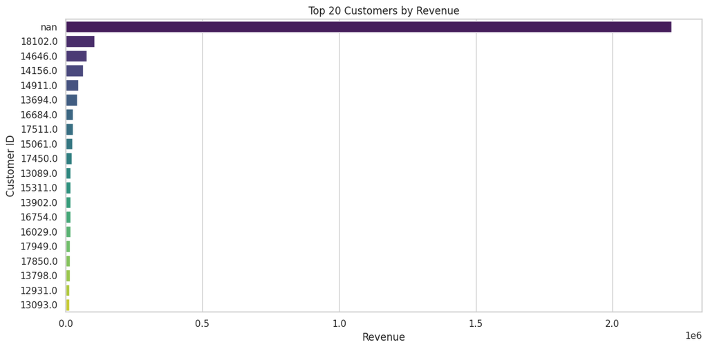

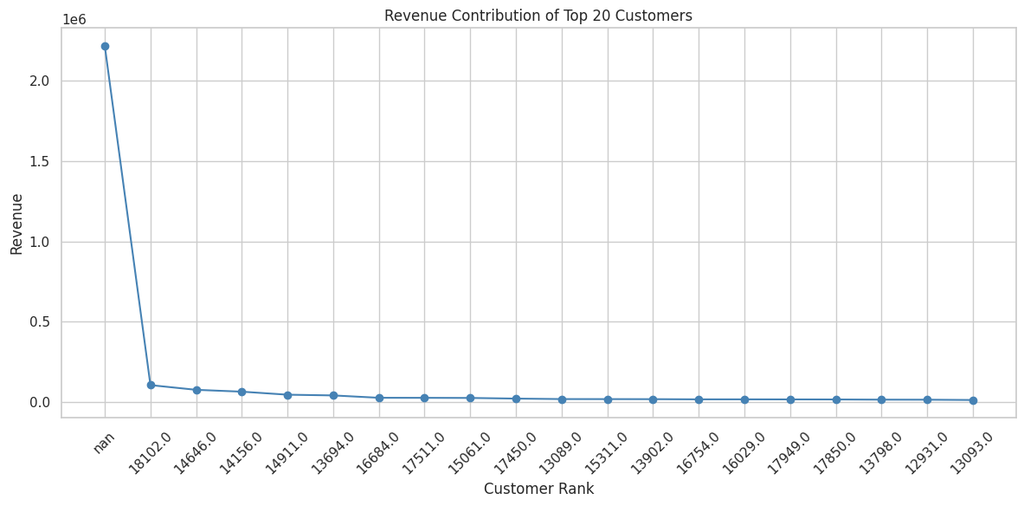

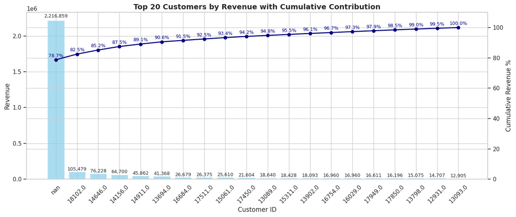

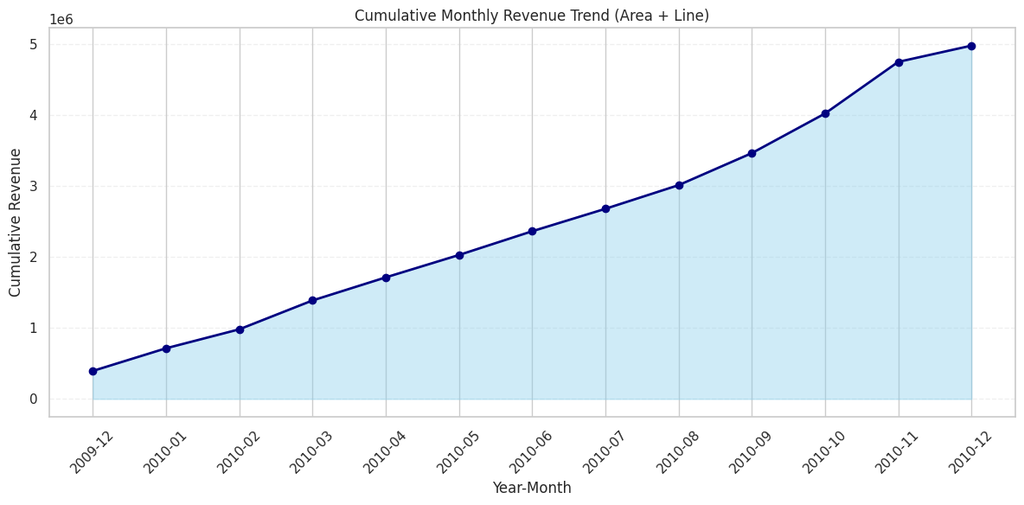

```python
# Filter out cancellations
df_q4 = df[df['is_cancellation'] == False].copy()

# Compute total revenue per customer
customer_revenue = df_q4.groupby('customer_id')['total_value'].sum().sort_values(ascending=False).head(20)

# Bar Chart
plt.figure(figsize=(12,6))
sns.barplot(x=customer_revenue.values, y=customer_revenue.index.astype(str), palette='viridis')
plt.title('Top 20 Customers by Revenue')
plt.xlabel('Revenue')
plt.ylabel('Customer ID')
plt.tight_layout()
plt.show()

# Horizontal Line Chart (Trend/Contribution)
plt.figure(figsize=(12,6))
plt.plot(customer_revenue.values, marker='o', color='steelblue')
plt.title('Revenue Contribution of Top 20 Customers')
plt.xlabel('Customer Rank')
plt.ylabel('Revenue')
plt.xticks(range(20), customer_revenue.index.astype(str), rotation=45)
plt.grid(True)
plt.tight_layout()
plt.show()

# Filter out cancellations
df_q15 = df[df['is_cancellation']==False].copy()

# Calculate total revenue per customer
customer_revenue = df_q15.groupby('customer_id')['total_value'].sum().reset_index()
customer_revenue = customer_revenue.sort_values('total_value', ascending=False)

# Select top 20 customers for clarity
top_customers = customer_revenue.head(20)
top_customers['cumulative_pct'] = top_customers['total_value'].cumsum() / top_customers['total_value'].sum() * 100

# Pareto Bar + Line Chart
fig, ax1 = plt.subplots(figsize=(14,6))

# Bar chart: revenue per customer
bars = ax1.bar(top_customers['customer_id'].astype(str), top_customers['total_value'], color='skyblue', alpha=0.7)
ax1.set_xlabel("Customer ID")
ax1.set_ylabel("Revenue")
ax1.set_title("Top 20 Customers by Revenue with Cumulative Contribution", fontsize=14, weight='bold')
ax1.tick_params(axis='x', rotation=45)

# Line chart: cumulative %
ax2 = ax1.twinx()
ax2.plot(top_customers['customer_id'].astype(str), top_customers['cumulative_pct'], color='navy', marker='o', linewidth=2)
ax2.set_ylabel("Cumulative Revenue %")
ax2.set_ylim(0, 110)

# Annotate bars
for bar, rev in zip(bars, top_customers['total_value']):
    ax1.text(bar.get_x() + bar.get_width()/2, rev + 0.01*rev, f"{int(rev):,}", ha='center', va='bottom', fontsize=9)

# Annotate cumulative %
for i, pct in enumerate(top_customers['cumulative_pct']):
    ax2.text(i, pct + 1, f"{pct:.1f}%", ha='center', va='bottom', fontsize=9, color='navy')

plt.tight_layout()
plt.show()

# Filter cancellations
df_q14 = df[df['is_cancellation']==False].copy()

# Ensure datetime
df_q14['invoice_date'] = pd.to_datetime(df_q14['invoicedate'])
df_q14['year_month'] = df_q14['invoice_date'].dt.to_period('M')

# Aggregate monthly revenue
monthly_revenue = df_q14.groupby('year_month')['total_value'].sum().reset_index()
monthly_revenue['cum_revenue'] = monthly_revenue['total_value'].cumsum()

# Area Chart for cumulative revenue
plt.figure(figsize=(12,6))
plt.fill_between(monthly_revenue['year_month'].astype(str), monthly_revenue['cum_revenue'], color='skyblue', alpha=0.4)
plt.plot(monthly_revenue['year_month'].astype(str), monthly_revenue['cum_revenue'], color='navy', linewidth=2, marker='o')
plt.xticks(rotation=45)
plt.xlabel("Year-Month")
plt.ylabel("Cumulative Revenue")
plt.title("Cumulative Monthly Revenue Trend (Area + Line)")
plt.grid(axis='y', linestyle='--', alpha=0.3)
plt.tight_layout()
plt.show()
```

Business Question 3:

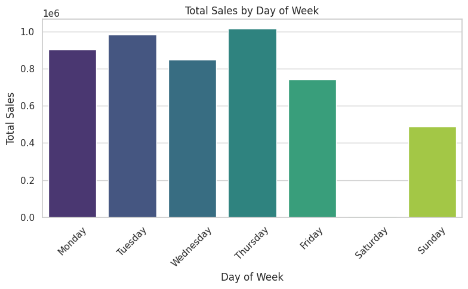

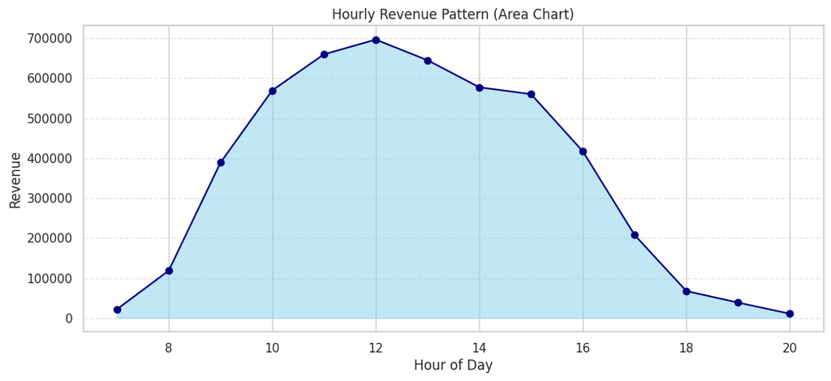

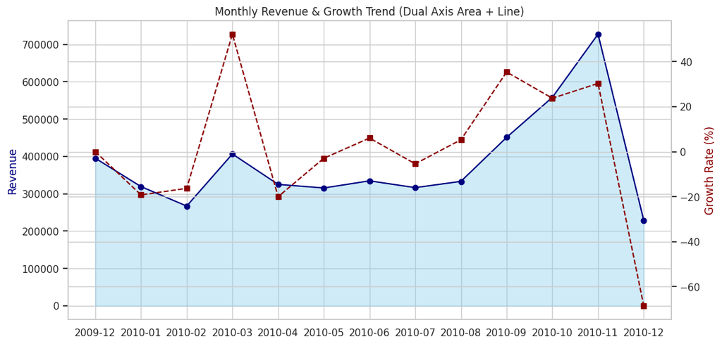

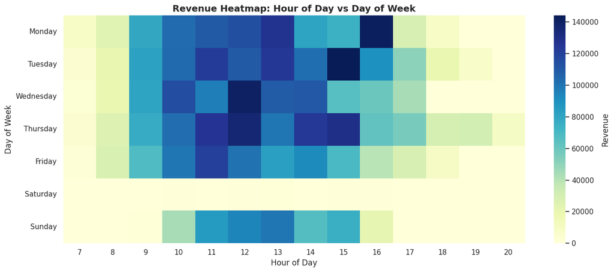

```python
# Keep only non-return sales
sales_only = df[df['quantity'] > 0].copy()
dow_sales = sales_only.groupby('day_of_week')['total_value'].sum()
dow_sales = dow_sales.reindex(['Monday','Tuesday','Wednesday','Thursday','Friday','Saturday','Sunday'])

plt.figure(figsize=(8,5))
sns.barplot(x=dow_sales.index, y=dow_sales.values, palette="viridis")
plt.title('Total Sales by Day of Week')
plt.ylabel('Total Sales')
plt.xlabel('Day of Week')
plt.xticks(rotation=45)
plt.tight_layout()
plt.show()

df_q18 = df[df['is_cancellation']==False].copy()

# Aggregate revenue per hour
hourly_revenue = df_q18.groupby('hour')['total_value'].sum().reset_index()



# Area Chart
plt.figure(figsize=(12,5))
plt.fill_between(hourly_revenue['hour'], hourly_revenue['total_value'], color='skyblue', alpha=0.5)
plt.plot(hourly_revenue['hour'], hourly_revenue['total_value'], marker='o', color='navy')
plt.title("Hourly Revenue Pattern (Area Chart)")
plt.xlabel("Hour of Day")
plt.ylabel("Revenue")
plt.grid(axis='y', linestyle='--', alpha=0.5)
plt.show()

df_q23 = df[df['is_cancellation']==False].copy()
df_q23['invoice_date'] = pd.to_datetime(df_q23['invoicedate'])
df_q23['year_month'] = df_q23['invoice_date'].dt.to_period('M')

monthly_rev = df_q23.groupby('year_month')['total_value'].sum().reset_index()
monthly_rev['growth_rate'] = monthly_rev['total_value'].pct_change().fillna(0)*100

fig, ax1 = plt.subplots(figsize=(12,6))

# Area for revenue
ax1.fill_between(monthly_rev['year_month'].astype(str), monthly_rev['total_value'], color='skyblue', alpha=0.4)
ax1.plot(monthly_rev['year_month'].astype(str), monthly_rev['total_value'], color='navy', marker='o')
ax1.set_ylabel("Revenue", color="navy")

# Growth rate on secondary axis
ax2 = ax1.twinx()
ax2.plot(monthly_rev['year_month'].astype(str), monthly_rev['growth_rate'], color='darkred', marker='s', linestyle='--')
ax2.set_ylabel("Growth Rate (%)", color="darkred")

plt.title("Monthly Revenue & Growth Trend (Dual Axis Area + Line)")
plt.xticks(rotation=45)
plt.show()

df_q9 = df[df['is_cancellation']==False].copy()
df_q9['hour'] = df_q9['invoicedate'].dt.hour
df_q9['day_of_week'] = df_q9['invoicedate'].dt.day_name()

# Revenue pivot by day & hour
heat_data = df_q9.pivot_table(
    values='total_value',
    index='day_of_week',
    columns='hour',
    aggfunc='sum'
).fillna(0)

# Reorder days (Mon-Sun)
days_order = ['Monday','Tuesday','Wednesday','Thursday','Friday','Saturday','Sunday']
heat_data = heat_data.reindex(days_order)

plt.figure(figsize=(14,6))
sns.heatmap(heat_data, cmap='YlGnBu', annot=False, cbar_kws={'label':'Revenue'})
plt.title("Revenue Heatmap: Hour of Day vs Day of Week", fontsize=14, weight='bold')
plt.xlabel("Hour of Day")
plt.ylabel("Day of Week")
plt.tight_layout()
plt.show()
```

Business Question 4:

Assess the contribution of top-selling products to overall revenue, track their hourly revenue trends, and compute cumulative revenue contributions to distinguish between high-performing and underperforming SKUs. Examine “Other” product categories to evaluate the long tail effect on revenue.

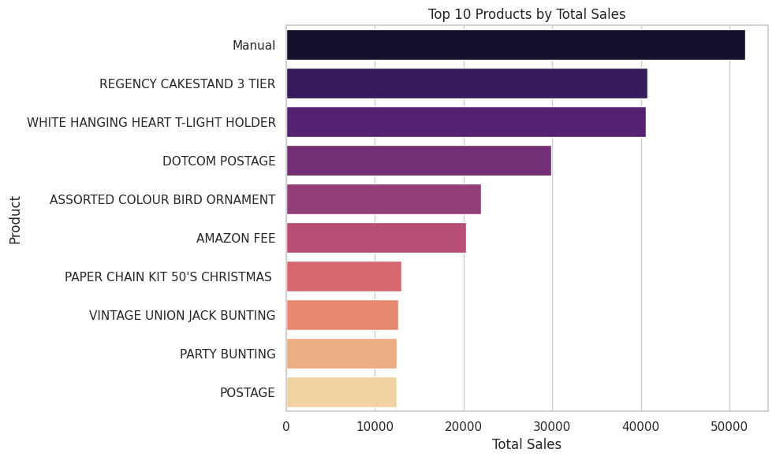

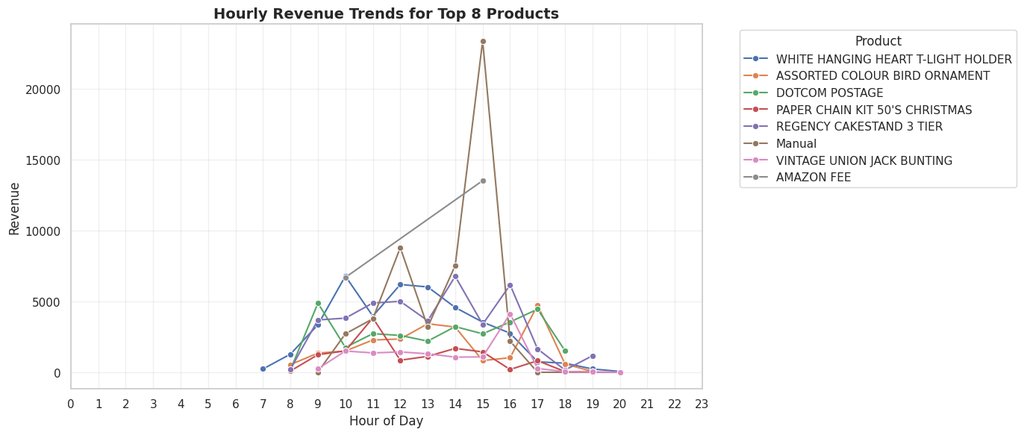

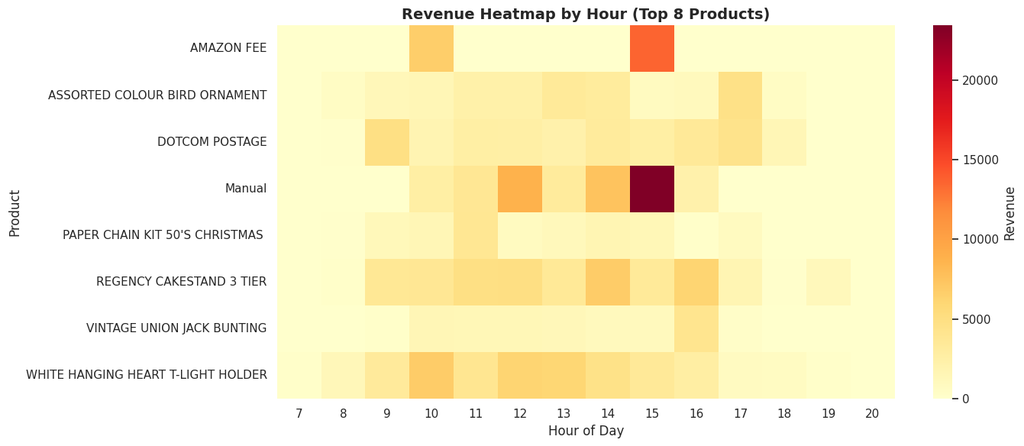

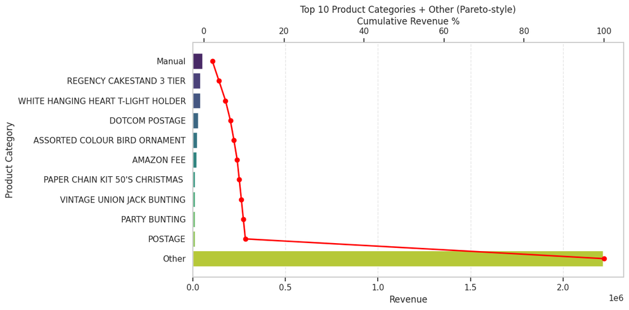

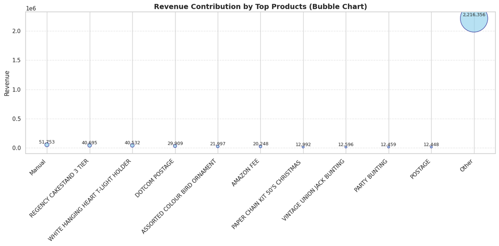

```python
top_products = (sales_only.groupby('description')['total_value']
                .sum()
                .sort_values(ascending=False)
                .head(10))

plt.figure(figsize=(10,6))
sns.barplot(x=top_products.values, y=top_products.index, palette="magma")
plt.title('Top 10 Products by Total Sales')
plt.xlabel('Total Sales')
plt.ylabel('Product')
plt.tight_layout()
plt.show()


# Prepare data
df_q26 = df[df['is_cancellation']==False].copy()

# Aggregate revenue by hour & product
hourly_revenue = df_q26.groupby(['hour','description'])['total_value'].sum().reset_index()

# Top 8 products overall
top_products = df_q26.groupby('description')['total_value'].sum().nlargest(8).index
hourly_top = hourly_revenue[hourly_revenue['description'].isin(top_products)]

#  Line Chart: Hourly revenue trends for top products
plt.figure(figsize=(14,6))
sns.lineplot(data=hourly_top, x='hour', y='total_value', hue='description', marker='o')
plt.title("Hourly Revenue Trends for Top 8 Products", fontsize=14, weight='bold')
plt.xlabel("Hour of Day")
plt.ylabel("Revenue")
plt.xticks(range(0,24))
plt.grid(alpha=0.3)
plt.legend(title="Product", bbox_to_anchor=(1.05,1), loc='upper left')
plt.tight_layout()
plt.show()

# --- Heatmap: Revenue intensity by hour & product ---
pivot_table = hourly_top.pivot(index='description', columns='hour', values='total_value').fillna(0)

plt.figure(figsize=(14,6))
sns.heatmap(pivot_table, cmap="YlOrRd", annot=False, cbar_kws={'label':'Revenue'})
plt.title("Revenue Heatmap by Hour (Top 8 Products)", fontsize=14, weight='bold')
plt.xlabel("Hour of Day")
plt.ylabel("Product")
plt.tight_layout()
plt.show()


# Filter cancellations
df_q11 = df[df['is_cancellation']==False].copy()

# Aggregate revenue by product description
product_revenue = (
    df_q11.groupby('description')['total_value']
    .sum()
    .reset_index()
    .sort_values('total_value', ascending=False)
)

# Top 10 + Other
top10 = product_revenue.head(10)
other_sum = pd.DataFrame({'description': ['Other'], 'total_value':[product_revenue['total_value'].iloc[10:].sum()]})
final_data = pd.concat([top10, other_sum]).reset_index(drop=True)

# Compute cumulative percentage
final_data['cum_pct'] = final_data['total_value'].cumsum() / final_data['total_value'].sum() * 100

# Pareto Horizontal Bar + Line
fig, ax1 = plt.subplots(figsize=(12,6))

# Horizontal bar
sns.barplot(data=final_data, y='description', x='total_value', palette='viridis', ax=ax1)
ax1.set_xlabel("Revenue")
ax1.set_ylabel("Product Category")
ax1.set_title("Top 10 Product Categories + Other (Pareto-style)")
ax1.grid(axis='x', linestyle='--', alpha=0.5)

# Cumulative percentage line
ax2 = ax1.twiny()
ax2.plot(final_data['cum_pct'], final_data['description'], color='red', marker='o', linewidth=2)
ax2.set_xlabel("Cumulative Revenue %")
ax2.grid(False)

plt.tight_layout()
plt.show()


# Filter out cancellations
df_q13 = df[df['is_cancellation'] == False].copy()

# Aggregate revenue per product (description)
product_revenue = df_q13.groupby('description')['total_value'].sum().reset_index()
product_revenue = product_revenue.sort_values('total_value', ascending=False)

# Take top 10 products, rest as 'Other'
top_n = 10
top_products = product_revenue.head(top_n)
other_sum = product_revenue['total_value'][top_n:].sum()
other_row = pd.DataFrame([{'description':'Other', 'total_value':other_sum}])
top_products = pd.concat([top_products, other_row], ignore_index=True)

#  Bubble Chart
plt.figure(figsize=(14,7))

# Scale bubble size
sizes = top_products['total_value'] / top_products['total_value'].max() * 3000  # adjust scaling factor

# Scatter plot
plt.scatter(top_products['description'], top_products['total_value'], s=sizes,
            alpha=0.6, color='skyblue', edgecolor='navy', linewidth=1.2)

# Annotate each bubble
for i, row in top_products.iterrows():
    plt.text(i, row['total_value'] + 0.01*row['total_value'], f"{int(row['total_value']):,}",
             ha='center', va='bottom', fontsize=9)

plt.xticks(rotation=45, ha='right')
plt.ylabel("Revenue")
plt.title("Revenue Contribution by Top Products (Bubble Chart)", fontsize=14, weight='bold')
plt.grid(axis='y', linestyle='--', alpha=0.5)
plt.tight_layout()
plt.show()
```

Business Question 5:

Examine hourly revenue patterns alongside return rates to identify critical operational periods. Additionally, analyze revenue contributions across different order size categories to understand order value distribution and inform inventory and pricing strategies.Also identify active versus dormant customer cohorts and analyze their contribution to revenue to optimize retention strategies and lifecycle management.

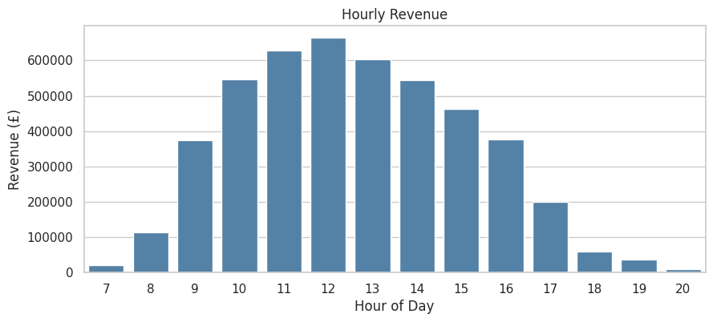

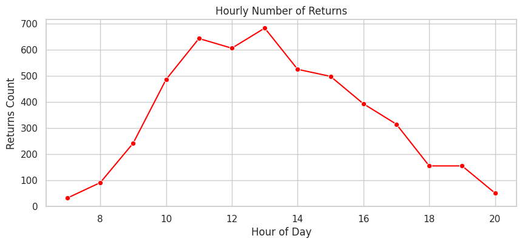

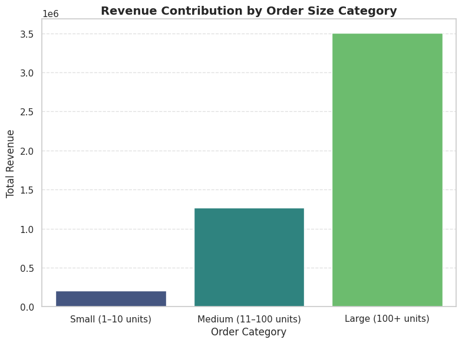

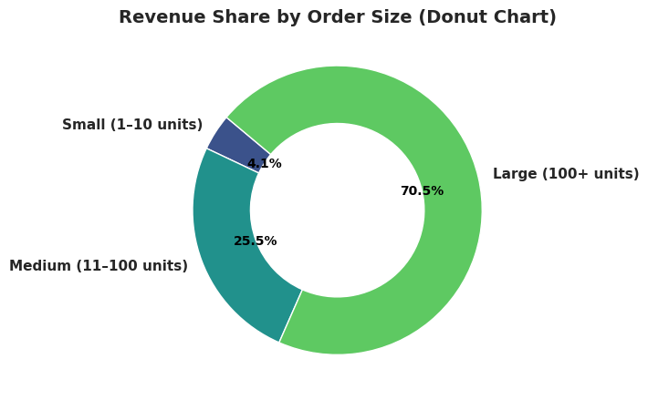

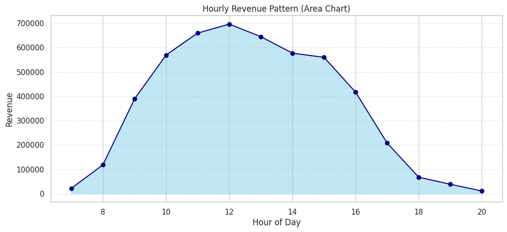

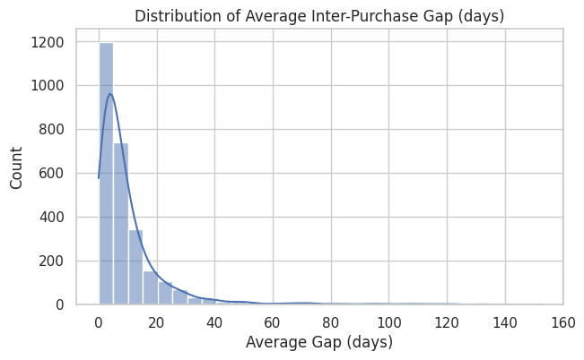

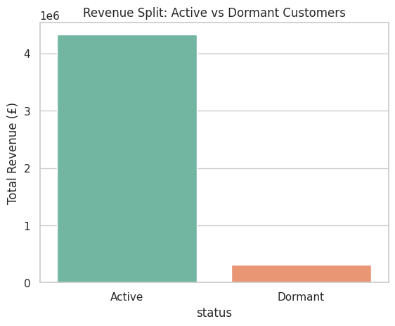

```python
hourly = (
    df.groupby('hour')
      .agg(revenue=('total_value','sum'),
           returns=('is_return','sum'))
      .reset_index()
)

plt.figure(figsize=(10,4))
sns.barplot(x='hour', y='revenue', data=hourly, color='steelblue')
plt.title('Hourly Revenue')
plt.xlabel('Hour of Day')
plt.ylabel('Revenue (£)')
plt.show()

plt.figure(figsize=(10,4))
sns.lineplot(x='hour', y='returns', data=hourly, marker='o', color='red')
plt.title('Hourly Number of Returns')
plt.xlabel('Hour of Day')
plt.ylabel('Returns Count')
plt.show()



warnings.filterwarnings("ignore")

# Filter out cancellations
df_q10 = df[df['is_cancellation']==False].copy()

# Units per invoice
order_sizes = df_q10.groupby('invoice')['quantity'].sum().reset_index()

# Revenue per invoice
invoice_revenue = df_q10.groupby('invoice')['total_value'].sum().reset_index()
order_sizes = order_sizes.merge(invoice_revenue, on='invoice')

#Categorize orders into bins
bins = [0, 10, 100, float('inf')]
labels = ['Small (1–10 units)', 'Medium (11–100 units)', 'Large (100+ units)']
order_sizes['order_category'] = pd.cut(order_sizes['quantity'], bins=bins, labels=labels)

# Revenue contribution by category
category_revenue = order_sizes.groupby('order_category')['total_value'].sum().reset_index()

#  Stacked Bar Chart
plt.figure(figsize=(8,6))
sns.barplot(data=category_revenue, x="order_category", y="total_value", palette="viridis")
plt.title("Revenue Contribution by Order Size Category", fontsize=14, weight='bold')
plt.xlabel("Order Category")
plt.ylabel("Total Revenue")
plt.grid(axis="y", linestyle="--", alpha=0.6)
plt.tight_layout()
plt.show()

# --- Pie Chart (Donut) ---
plt.figure(figsize=(7,7))
wedges, texts, autotexts = plt.pie(
    category_revenue['total_value'],
    labels=category_revenue['order_category'],
    autopct='%1.1f%%',
    startangle=140,
    colors=sns.color_palette("viridis", len(category_revenue)),
    wedgeprops=dict(width=0.4)
)

# Improve label visibility
for text in texts:
    text.set(size=11, weight="bold")
for autotext in autotexts:
    autotext.set(size=10, weight="bold", color="black")

plt.title("Revenue Share by Order Size (Donut Chart)", fontsize=14, weight='bold')
plt.tight_layout()
plt.show()

df_q18 = df[df['is_cancellation']==False].copy()

# Aggregate revenue per hour
hourly_revenue = df_q18.groupby('hour')['total_value'].sum().reset_index()



# Area Chart
plt.figure(figsize=(12,5))
plt.fill_between(hourly_revenue['hour'], hourly_revenue['total_value'], color='skyblue', alpha=0.5)
plt.plot(hourly_revenue['hour'], hourly_revenue['total_value'], marker='o', color='navy')
plt.title("Hourly Revenue Pattern (Area Chart)")
plt.xlabel("Hour of Day")
plt.ylabel("Revenue")
plt.grid(axis='y', linestyle='--', alpha=0.5)
plt.show()




plt.figure(figsize=(7,4))
sns.histplot(cycle_df['avg_gap_days'], bins=30, kde=True)
plt.title('Distribution of Average Inter-Purchase Gap (days)')
plt.xlabel('Average Gap (days)')
plt.show()


cutoff_date = df['invoicedate'].max() - pd.Timedelta(days=90)
recent_cust = df[df['invoicedate'] > cutoff_date]['customer_id'].unique()

rfm = df.groupby('customer_id')['total_value'].sum().reset_index()
rfm['status'] = rfm['customer_id'].apply(lambda x: 'Active' if x in recent_cust else 'Dormant')



rev_status = rfm.groupby('status')['total_value'].sum().reset_index()
sns.barplot(x='status', y='total_value', data=rev_status, palette='Set2')
plt.title('Revenue Split: Active vs Dormant Customers')
plt.ylabel('Total Revenue (£)')
plt.show()
```

Business Question 6:

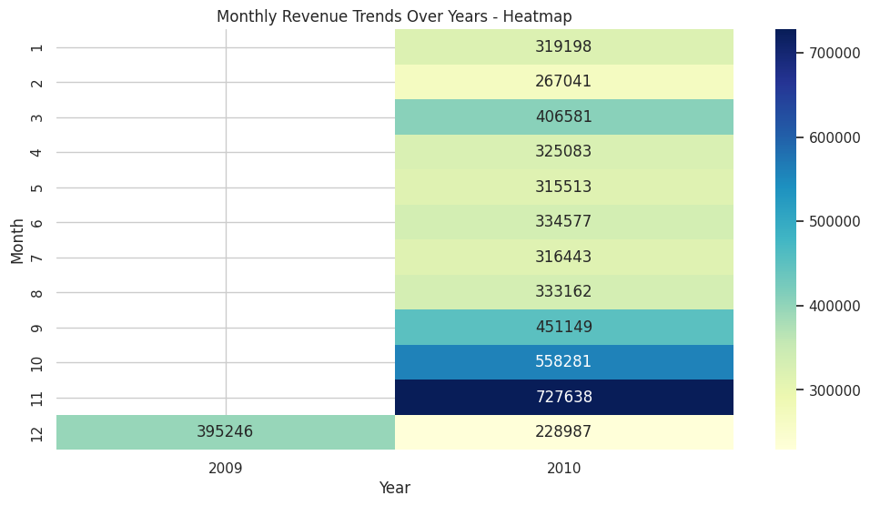

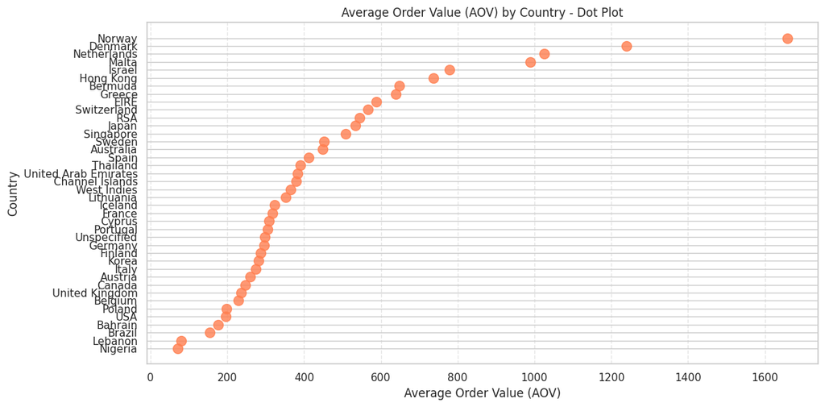

```python
df_q28 = df[df['is_cancellation']==False].copy()
df_q28['invoice_date'] = pd.to_datetime(df_q28['invoicedate'])
df_q28['month'] = df_q28['invoice_date'].dt.month
df_q28['year'] = df_q28['invoice_date'].dt.year

# Aggregate revenue
seasonal = df_q28.groupby(['year','month'])['total_value'].sum().reset_index()

# Pivot correctly using keyword arguments
seasonal_pivot = seasonal.pivot(index='month', columns='year', values='total_value')

# Heatmap
plt.figure(figsize=(12,6))
sns.heatmap(seasonal_pivot, annot=True, fmt=".0f", cmap="YlGnBu")
plt.title("Monthly Revenue Trends Over Years - Heatmap")
plt.ylabel("Month")
plt.xlabel("Year")
plt.show()


# Filter cancellations
df_q17 = df[df['is_cancellation']==False].copy()

# Aggregate: AOV per country
aov_country = df_q17.groupby('country').agg(
    total_value=('total_value','sum'),
    total_invoices=('invoice','nunique')
).reset_index()
aov_country['AOV'] = (aov_country['total_value'] / aov_country['total_invoices']).round(2)

# Sort by AOV
aov_country = aov_country.sort_values('AOV', ascending=True)


#  Dot Plot (alternative view)
plt.figure(figsize=(12,6))
plt.scatter(aov_country['AOV'], aov_country['country'], s=100, color='coral', alpha=0.8)
plt.xlabel("Average Order Value (AOV)")
plt.ylabel("Country")
plt.title("Average Order Value (AOV) by Country - Dot Plot")
plt.grid(axis='x', linestyle='--', alpha=0.5)
plt.tight_layout()
plt.show()
```

**References**

1.Provost, F. and Fawcett, T. (2013) Data Science for Business: What You Need to Know about Data Mining and Data-Analytic Thinking. O’Reilly Media.

2.McKinsey & Company (2018) The Future of Retail Operations. Available at: https://www.mckinsey.com (Accessed: 20 September 2025).

3.Pandas Documentation (2025) Python Data Analysis Library. Available at: https://pandas.pydata.org (Accessed: 20 September 2025).

4.Seaborn Documentation (2025) Statistical Data Visualization. Available at: https://seaborn.pydata.org (Accessed: 20 September 2025).